# Gapminder Dataset Exploration And Correlation Between Inequality, Life Expectancy, and Sugar Consumption

14th of September 2023

## Introduction

The App is a quick way to compare different countries, in regards to inequality, sugar consumption and life expectancy from the early 60’s till 2018.

The app also helps show the correlation between the two data sets the user chooses and shows the regression coefficient between the two variable in the years and locations selected

## The input selection

The sidebar allows you to select:

- 3 countries each selected through a slide down menu
- 2 data sets, each selected through a slide down menu
- The range of years required, where you can add the minimum and maximum years in the slider

## First Tab

Includes two line graphs to show evolution of selected variables in specified countries.

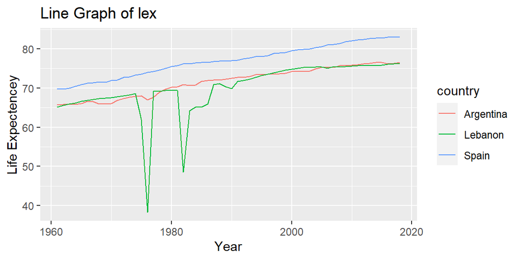

Line Graph of Life Expectancy

```r
ggplot(data1, aes(x = year, lex , color = country)) +
      geom_line() +
      labs(title = paste("Line Graph of lex"),
           x = "Year",
           y = "Life Expectencey")
```

## Second Tab

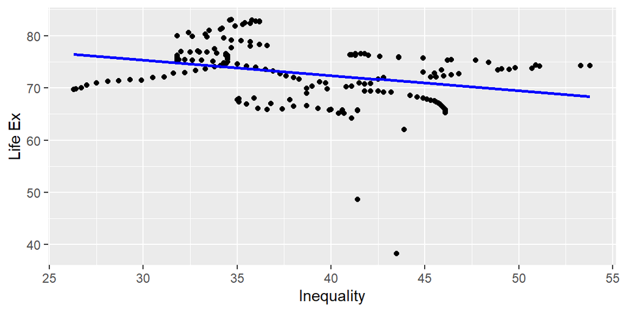

Regression of Life Expectancy and Inequality

```r
ggplot(data1, aes(x = gini , lex)) +
  geom_point() +
  geom_smooth(method = "lm", se = FALSE, color = "blue") +
  labs(x = "Inequality", y = "Life Ex")
```

## Third Tab

Has Descriptions of data shorthands and meaning, you can see how it looks in-app below

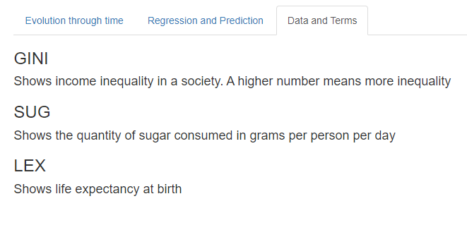

## Links

- The app can be found [here](https://berj.shinyapps.io/single/)
- The data can be found [here](https://www.gapminder.org/data/)
- The code can be found [here](https://github.com/BerjDek/Final_DDO/tree/main/)